# Lecture 04 — Testing Our Hypothesis

The two-sample Welch’s t-test from assumptions to results

Bill Perry

2026-07-02

# Where we left off (Lecture 03)

- **Wrangling** — `filter()`, `select()`, `mutate()`, `arrange()` as the core tidyverse verbs
- **Descriptive stats** — mean, median, SD, SE with `group_by()` + `summarize()`
- **NA handling** — `sum(!is.na())` is the safe way to count *n*
- **`skimr`** — fast full-dataset overview in one line
- **Boxplot** + jittered points; **mean ± SE** with `stat_summary()`
- **Finding:** shady leaves appear heavier, taller, and wider than sunny leaves

**Note**

**✅ Key idea from Lecture 03**

We described the pattern in our data. Today we formally test whether that pattern is *statistically significant*.

# Goals for Today

- **Understand** why comparing means is not enough — we need a test
- **State** null and alternate hypotheses formally
- **Check assumptions** before running any test
  - normality: histogram, QQ plot, Shapiro-Wilk
  - variance: Levene’s test
- **Run** Welch’s two-sample t-test in R
- **Read** every line of the `t.test()` output
- **Report** results in scientific writing format

**Tip**

**🖐 Try it yourself**

By the end you will run and interpret a complete t-test on our leaf data.

**Tools added today:**

- `car` — Levene’s variance test

**References:**

- 📖 [R4DS §3](https://r4ds.hadley.nz/data-transform)
- 🌐 [Data Carpentry](https://datacarpentry.github.io/R-ecology-lesson/)

**Today’s naming:**

- test objects → `_model`
- plots → `_plot`

# Our Hypotheses — A Reminder

**Biological prediction:**

Shady-side leaves will be **larger and heavier** — they need more surface area to capture the limited light filtering through the canopy.

|  | Formal statement |
| --- | --- |
| **H₀ — null** | $\mu_{shady} = \mu_{sunny}$ — no difference in mean leaf weight |
| **Hₐ — alternate** | $\mu_{shady} \neq \mu_{sunny}$ — mean leaf weight differs by side |

We use a **two-tailed** test — we will detect a difference in *either* direction.

**Why two-tailed?**

- We predicted shady > sunny
- A one-tailed test would only reject H₀ in that direction
- Two-tailed is **more conservative** and more broadly accepted
- If the result is significant two-tailed, it is also significant one-tailed

**α = 0.05** — our threshold for rejecting H₀

# Load Libraries and Data

```r
# Load all packages at the top ----------------------------
library(readxl) # reading Excel files
library(tidyverse) # data manipulation + ggplot2
library(skimr) # fast summaries
library(car) # Levene's test for variance equality
```

```r
# Load the leaf data from the data folder -----------------
tree_df <- read_excel("data/2026_06_25_tree_experiment_raw_data.xlsx")
```

**Note**

`car` is the **C**ompanion to **A**pplied **R**egression package. It contains `leveneTest()`, which we use to check whether our two groups have similar variance.

Install once: `install.packages("car")`

# What We Know So Far

```r
# Quick recap from Lecture 03 ----------------------------
recap_df <- tree_df %>%
  group_by(side) %>%
  summarize(
    n = sum(!is.na(weight_g)),
    mean_wt = round(mean(weight_g, na.rm = TRUE), 2),
    sd_wt = round(sd(weight_g, na.rm = TRUE), 2),
    se_wt = round(sd_wt / sqrt(n), 2)
  )
recap_df
```

```
# A tibble: 2 × 5
  side      n mean_wt sd_wt se_wt
  <chr> <int>   <dbl> <dbl> <dbl>
1 shady    10     7.8  1.03  0.33
2 sunny    10     3.8  0.79  0.25
```

- RESULTS:
  - Shady mean: **7.80 g**
  - Sunny mean: **3.80 g**
  - Difference: **4.0 g** — a big gap!
- **But is that gap real, or could it just be sampling noise?**
- With only n = 10 per group, random chance could produce apparent differences.
- **We need a formal test to quantify the probability.**

# Why Comparing Means Is Not Enough

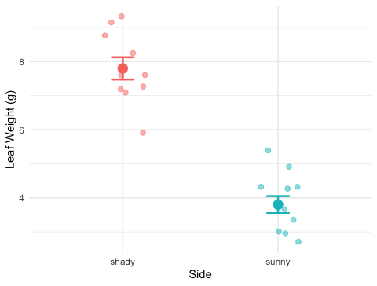

```r
# Remind ourselves what the data look like ---------------
recap_plot <- tree_df %>%
  ggplot(aes(x = side, y = weight_g, color = side)) +
  geom_point(
    position = position_jitter(width = 0.15, seed = 42),
    alpha = 0.5,
    size = 2
  ) +
  stat_summary(fun = mean, geom = "point", size = 4) +
  stat_summary(
    fun.data = mean_se,
    geom = "errorbar",
    width = 0.15,
    linewidth = 0.9
  ) +
  labs(x = "Side", y = "Leaf Weight (g)") +
  theme_minimal() +
  theme(legend.position = "none")
recap_plot
```

The means look different — but:

A *p*-value tells us:

> *“If H₀ were true, how often would we see a gap this large just by chance?”*

Small *p* → the gap is unlikely to be chance.

# What Is a Two-Sample t-Test?

A two-sample t-test compares the **means of two independent groups**.

It asks: *Could both groups plausibly be drawn from populations with the same mean?*

The **t-statistic** is:

$$t = \frac{\bar{x}_1 - \bar{x}_2}{\text{SE}_{\text{diff}}}$$

- Numerator: the **observed difference** in means
- Denominator: the **uncertainty** in that difference (SE of the difference)

**Large |t|** → the difference is large relative to the noise → small *p*-value

| Component | Our context |
| --- | --- |
| Group 1 | Shady leaves |
| Group 2 | Sunny leaves |
| Measurement | `weight_g` |
| H₀ | $\mu_{shady} = \mu_{sunny}$ |
| Hₐ | $\mu_{shady} \neq \mu_{sunny}$ |

# Why Welch’s? — Don’t Assume Equal Variance

**Standard t-test** — pools the two variances into one estimate. Requires both groups to have the **same population variance**.

**Welch’s t-test** — uses each group’s variance separately. Does **not** require equal variance.

$$t_W = \frac{\bar{x}_1 - \bar{x}_2}{\sqrt{\dfrac{s_1^2}{n_1} + \dfrac{s_2^2}{n_2}}}$$

The denominator is the **true SE of the difference** — no pooling.

**Why always use Welch’s?**

- When variances **are** equal: almost identical result — minimal loss of power
- When variances **are not** equal: standard t-test gives **inflated Type I error** (false positives)
- **Welch’s protects you either way**

**Tip**

**Best practice:** use Welch’s as your **default** for all two-group comparisons.

In R: **`var.equal = FALSE`**

# The Welch’s Formula in Action

```r
# Pull stats and compute t by hand ----------------------
stats_df <- tree_df %>%
  group_by(side) %>%
  summarize(
    n = sum(!is.na(weight_g)),
    m = mean(weight_g, na.rm = TRUE),
    s = sd(weight_g, na.rm = TRUE)
  )

m_sha <- stats_df$m[stats_df$side == "shady"]
m_sun <- stats_df$m[stats_df$side == "sunny"]
s_sha <- stats_df$s[stats_df$side == "shady"]
s_sun <- stats_df$s[stats_df$side == "sunny"]
n_sha <- stats_df$n[stats_df$side == "shady"]
n_sun <- stats_df$n[stats_df$side == "sunny"]

se_diff <- sqrt((s_sha^2 / n_sha) + (s_sun^2 / n_sun))
t_manual <- (m_sha - m_sun) / se_diff

cat("Difference in means:", round(m_sha - m_sun, 2), "g\n")
```

```
Difference in means: 4 g
```

```r
cat("SE of difference:   ", round(se_diff, 4), "\n")
```

```
SE of difference:    0.411
```

```r
cat("t-statistic:        ", round(t_manual, 3), "\n")
```

```
t-statistic:         9.733
```

**Step by step:**

1. Difference in means: 7.80 − 3.80 = **4.0 g**
2. SE of the difference: $\sqrt{\frac{s^2_{shady}}{10} + \frac{s^2_{sunny}}{10}}$
3. t = difference / SE

The observed difference is ~10 standard errors above zero — very far from what we’d expect if H₀ were true.

# Five Steps to a Hypothesis Test

We will always follow this sequence:

| Step | Action |
| --- | --- |
| **1** | State H₀ and Hₐ |
| **2** | Check **normality** — histogram/box plot |
| **3** | Check **normality** — QQ plot + Shapiro-Wilk |
| **4** | Check **variance** — Levene’s test |
| **5** | **Run** the test; **interpret** and **report** |

**Important**

**Check assumptions BEFORE running the test.**

If your data seriously violate assumptions, the *p*-value from the t-test is unreliable.

With n = 10 per group, our main concern is **gross non-normality**. The t-test is quite robust to mild departures.

# Step 1 — Hypotheses (Formal)

**Null hypothesis:**

$$H_0: \mu_{shady} = \mu_{sunny}$$

Shady and sunny leaves have the **same mean weight** in the population.

**Alternate hypothesis (two-tailed):**

$$H_A: \mu_{shady} \neq \mu_{sunny}$$

The mean leaf weights **differ** between sides — in either direction.

**Significance level:** α = 0.05

We will reject H₀ if *p* < 0.05.

**Why state hypotheses first?**

- Keeps the analysis honest
- Prevents “HARKing” (Hypothesizing After Results are Known)
- Forces you to commit to a direction (one-tailed) or not (two-tailed) before seeing the data

**Our commitment:** two-tailed, α = 0.05, before running any test.

# Step 2 — Check Normality: Histogram

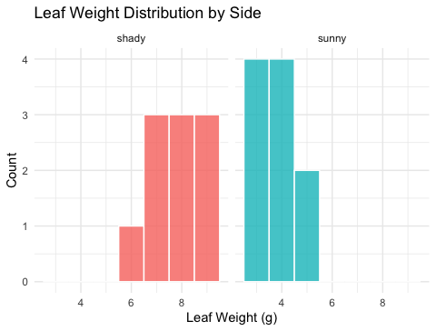

```r
# Histogram per group to visually check normality -------
hist_norm_plot <- tree_df %>%
  ggplot(aes(x = weight_g, fill = side)) +
  geom_histogram(binwidth = 1, color = "white", alpha = 0.8) +
  facet_wrap(~side, ncol = 2) +
  labs(
    title = "Leaf Weight Distribution by Side",
    x = "Leaf Weight (g)",
    y = "Count"
  ) +
  theme_minimal() +
  theme(legend.position = "none")
hist_norm_plot
```

**What to look for:**

- Roughly **bell-shaped** — not heavily skewed
- No obvious **bimodal** peaks
- No extreme **outliers**

With n = 10 per group, histograms look lumpy — that is **normal for small samples**.

Histograms are a visual check only. We also use QQ plots and Shapiro-Wilk.

# Step 3 — Check Normality: QQ Plot

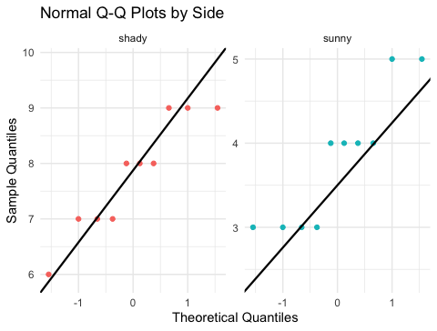

```r
# Q-Q plot — points should fall along the diagonal line --
qq_norm_plot <- tree_df %>%
  ggplot(aes(sample = weight_g, color = side)) +
  stat_qq() +
  stat_qq_line(color = "black", linewidth = 0.8) +
  facet_wrap(~side, scales = "free") +
  labs(
    title = "Normal Q-Q Plots by Side",
    x = "Theoretical Quantiles",
    y = "Sample Quantiles"
  ) +
  theme_minimal() +
  theme(legend.position = "none")
qq_norm_plot
```

**How to read a QQ plot:**

- Points **on the line** → data follow a normal distribution
- Points **curving away** at ends → heavy tails or skew
- With only n = 10, some deviation is expected and acceptable

If points follow the line roughly, we are comfortable proceeding with the t-test.

# Step 3 — Check Normality: Shapiro-Wilk Test

```r
# Shapiro-Wilk test for the sunny side -----------------
tree_df %>%
  filter(side == "sunny") %>%
  pull(weight_g) %>%
  shapiro.test()
```

```
    Shapiro-Wilk normality test

data:  .
W = 0.8197, p-value = 0.02513
```

```r
# Shapiro-Wilk test for the shady side -----------------
tree_df %>%
  filter(side == "shady") %>%
  pull(weight_g) %>%
  shapiro.test()
```

```
    Shapiro-Wilk normality test

data:  .
W = 0.89461, p-value = 0.191
```

**Shapiro-Wilk H₀:** the data are normally distributed.

- *p* > 0.05 → **fail to reject** normality → proceed with t-test
- *p* < 0.05 → evidence of non-normality → consider a non-parametric alternative

**Important**

**Small-sample caution:**

With n = 10, this test has **low power** — it rarely detects non-normality even when present. The QQ plot is equally important.

# Step 4 — Check Variance: Levene’s Test

```r
# Levene's test — are the variances similar? -----------
leveneTest(weight_g ~ side, data = tree_df)
```

```
Levene's Test for Homogeneity of Variance (center = median)
      Df F value Pr(>F)
group  1     0.6 0.4486
      18
```

**Levene’s test H₀:** the two groups have **equal variance**.

- *p* > 0.05 → variances are not significantly different
- *p* < 0.05 → variances are significantly different

**Our response regardless of the result:**

We will use Welch’s t-test (`var.equal = FALSE`).

Welch’s is valid whether or not the variances are equal. We run Levene’s to *understand our data*, not to choose our test.

# Step 5 — Run the Welch’s t-Test

```r
# Welch's two-sample t-test — unequal variance ---------
leaf_ttest_model <- t.test(
  weight_g ~ side, # formula: response ~ grouping variable
  data = tree_df,
  var.equal = FALSE, # Welch's — no pooled variance
  alternative = "two.sided" # two-tailed test
)

leaf_ttest_model
```

```
    Welch Two Sample t-test

data:  weight_g by side
t = 9.7333, df = 16.834, p-value = 2.514e-08
alternative hypothesis: true difference in means between group shady and group sunny is not equal to 0
95 percent confidence interval:
 3.132297 4.867703
sample estimates:
mean in group shady mean in group sunny
                7.8                 3.8
```

**Key arguments:**

| argument | what it does |
| --- | --- |
| `weight_g ~ side` | compare `weight_g` between levels of `side` |
| `var.equal = FALSE` | use Welch’s correction |
| `alternative = "two.sided"` | two-tailed test |

The result is a model object. We decode each line of the output on the next slide.

# Reading the `t.test()` Output

```r
# Extract individual values from the model object ------
cat("t-statistic  :", round(leaf_ttest_model$statistic, 3), "\n")
```

```
t-statistic  : 9.733
```

```r
cat("df (Welch)   :", round(leaf_ttest_model$parameter, 2), "\n")
```

```
df (Welch)   : 16.83
```

```r
cat("p-value      :", signif(leaf_ttest_model$p.value, 3), "\n")
```

```
p-value      : 2.51e-08
```

```r
cat(
  "95% CI       :",
  round(leaf_ttest_model$conf.int[1], 2),
  "to",
  round(leaf_ttest_model$conf.int[2], 2),
  "g\n"
)
```

```
95% CI       : 3.13 to 4.87 g
```

```r
cat("Mean shady   :", round(leaf_ttest_model$estimate[1], 2), "g\n")
```

```
Mean shady   : 7.8 g
```

```r
cat("Mean sunny   :", round(leaf_ttest_model$estimate[2], 2), "g\n")
```

```
Mean sunny   : 3.8 g
```

**Line by line:**

| output | meaning |
| --- | --- |
| `t` | our calculated t-statistic |
| `df` | Welch-Satterthwaite df (non-integer is normal!) |
| `p-value` | probability of this result if H₀ is true |
| `95% CI` | plausible range for the true difference in means |
| `mean of shady/sunny` | the two group means |

The **95% CI** is the range we could expect to see if we repeated this study many times.

# Step 5 — Make a Decision

```r
# State the decision formally --------------------------
# if/else: R checks the condition and runs one of two blocks
# We will learn these formally in the functions lecture
p_val <- leaf_ttest_model$p.value
alpha <- 0.05

if (p_val < alpha) {
  cat("p =", signif(p_val, 3), "< α =", alpha, "\n")
  cat("Decision: REJECT H₀\n")
  cat("Conclusion: leaf weight differs between sides.\n")
} else {
  cat("p =", signif(p_val, 3), ">= α =", alpha, "\n")
  cat("Decision: FAIL TO REJECT H₀\n")
  cat("Conclusion: insufficient evidence of a difference.\n")
}
```

```
p = 2.51e-08 < α = 0.05
Decision: REJECT H₀
Conclusion: leaf weight differs between sides.
```

**Important**

**What a small p-value means:**

If H₀ were true (no real difference), we would get a t-statistic this large or larger less than `p` × 100% of the time just by chance.

We set α = 0.05 *before* the test. If *p* < α, we reject H₀.

**What a small p-value does NOT mean:**

- It is not the probability that H₀ is true
- Statistical significance ≠ biological importance
- Report the effect size (difference in means) alongside *p*

# Visualize the Result — Boxplot

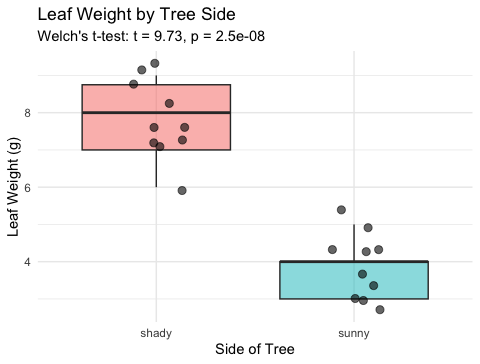

```r
# Final boxplot with all points -----------------------
leaf_box_04_plot <- tree_df %>%
  ggplot(aes(x = side, y = weight_g, fill = side)) +
  geom_boxplot(alpha = 0.5, outlier.shape = NA) +
  geom_point(
    position = position_jitter(width = 0.15, seed = 42),
    alpha = 0.6,
    size = 2.5
  ) +
  labs(
    title = "Leaf Weight by Tree Side",
    subtitle = paste0(
      "Welch's t-test: t = ",
      round(leaf_ttest_model$statistic, 2),
      ", p = ",
      signif(leaf_ttest_model$p.value, 2)
    ),
    x = "Side of Tree",
    y = "Leaf Weight (g)"
  ) +
  theme_minimal() +
  theme(legend.position = "none")
leaf_box_04_plot
```

**Including the test result in the figure:**

- `subtitle` pulls t and p directly from the model object
- R fills in the actual numbers automatically
- If you re-run with new data, the subtitle updates

**Tip**

Embedding test statistics in the plot subtitle saves you from copying numbers by hand — and avoids typos in your report.

# Visualize the Result — Mean ± SE

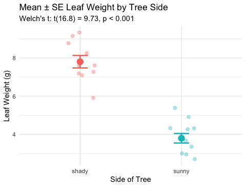

```r
# Mean ± SE plot with individual points ---------------
leaf_mean_se_04_plot <- tree_df %>%
  ggplot(aes(x = side, y = weight_g, color = side)) +
  geom_point(
    position = position_jitter(width = 0.15, seed = 42),
    alpha = 0.35,
    size = 2
  ) +
  stat_summary(fun = mean, geom = "point", size = 4) +
  stat_summary(
    fun.data = mean_se,
    geom = "errorbar",
    width = 0.15,
    linewidth = 0.9
  ) +
  labs(
    title = "Mean ± SE Leaf Weight by Tree Side",
    subtitle = paste0(
      "Welch's t: t(",
      round(leaf_ttest_model$parameter, 1),
      ") = ",
      round(leaf_ttest_model$statistic, 2),
      ", p < 0.001"
    ),
    x = "Side of Tree",
    y = "Leaf Weight (g)"
  ) +
  theme_minimal() +
  theme(legend.position = "none")
leaf_mean_se_04_plot
```

**What the error bars tell you:**

- Bars show **± 1 SE** — precision of the mean estimate
- Non-overlapping bars suggest a significant difference

**Rule of thumb:**

If error bars overlap by less than half the bar length, the difference is *likely* significant at α = 0.05. The *p*-value from the t-test is the definitive answer.

# How to Report Results in Science

```r
# Compute reporting values from the model object -------
t_val <- round(leaf_ttest_model$statistic, 2)
df_val <- round(leaf_ttest_model$parameter, 1)
p_val2 <- signif(leaf_ttest_model$p.value, 2)

cat("--- Results sentence ---\n")
```

```
--- Results sentence ---
```

```r
cat("Shady-side leaves were significantly heavier than\n")
```

```
Shady-side leaves were significantly heavier than
```

```r
cat(
  "sunny-side leaves (Welch's t-test: t(",
  df_val,
  ") =",
  t_val,
  ", p =",
  p_val2,
  ").\n"
)
```

```
sunny-side leaves (Welch's t-test: t( 16.8 ) = 9.73 , p = 2.5e-08 ).
```

```r
cat(
  "Mean ± SE: shady =",
  round(leaf_ttest_model$estimate[1], 2),
  "±",
  round(recap_df$se_wt[recap_df$side == "shady"], 2),
  "g,\n"
)
```

```
Mean ± SE: shady = 7.8 ± 0.33 g,
```

```r
cat(
  "           sunny =",
  round(leaf_ttest_model$estimate[2], 2),
  "±",
  round(recap_df$se_wt[recap_df$side == "sunny"], 2),
  "g.\n"
)
```

```
           sunny = 3.8 ± 0.25 g.
```

**Standard format:**

> *“[Finding] (Welch’s t-test: t(df) = X.XX, p = X.XXX; mean ± SE: group1 = X.X ± X.X units, group2 = X.X ± X.X units).”*

**Always include:**

- Test type (Welch’s t-test)
- t-statistic and df
- Exact *p*-value (or < 0.001)
- Group means ± SE
- Units

**Never report** “p = 0.000” — write “p < 0.001” instead.

# Save Your Plots

```r
# Save both plots to the figures folder ----------------
ggsave(
  "figures/leaf_weight_boxplot_ttest.png",
  plot = leaf_box_04_plot,
  width = 5,
  height = 5,
  units = "in",
  dpi = 300
)

ggsave(
  "figures/leaf_weight_mean_se_ttest.png",
  plot = leaf_mean_se_04_plot,
  width = 5,
  height = 5,
  units = "in",
  dpi = 300
)
```

Both plots are now in your `figures/` folder with the test statistics embedded in the subtitle — ready for a lab report or paper.

**Tip**

`dpi = 300` is publication quality. Use it for any figure that will appear in a paper, poster, or formal report.

# What We Learned Today

**Concepts:**

- Why we need a hypothesis test — means alone are not enough
- **Welch’s t-test** — use `var.equal = FALSE` as the safe default
- **Two-tailed** test — detects differences in either direction
- **Five-step framework** — hypotheses → normality → variance → test → report
- **Reading output** — t, df, *p*, CI, group means

**R skills:**

- `library(car)` + `leveneTest(y ~ group, data)` — variance check
- `filter() %>% pull() %>% shapiro.test()` — normality per group
- `t.test(y ~ group, data, var.equal = FALSE, alternative = "two.sided")`
- `model$statistic`, `model$p.value`, `model$conf.int` — extract results
- `paste0(...)` in subtitle — embed test statistics in figures

**References:**

- 📖 [R4DS §3](https://r4ds.hadley.nz/data-transform) — Data Transformation
- 📖 [R4DS §13](https://r4ds.hadley.nz/numbers) — Numbers
- 🌐 [Data Carpentry](https://datacarpentry.github.io/R-ecology-lesson/)

**Up next — Lecture 05:**

- Linear regression — predicting leaf area from paper tracing mass
- Building a calibration curve with `lm()`
- R², residuals, and assumption checking